# STA130H1 - Class # 1: Introduction to R, Histograms and Density Functions

2018-01-08

## Welcome to STA130H1

- Login to Portal to get the location of your tutorial room (look under My Groups).
- Let's explore the [course website](http://sta130.utstat.utoronto.ca/)

## A Brief Introduction to R

## What is R?

[figure not shown]

## R Coding basics

Go to console …

## Histograms and Density Functions

## Histograms and Density Functions

- The histogram of a variable is a graphical method to vizualize the distribution of a single variable.

## Histograms and Density Functions

- Different bin width will yield different histograms

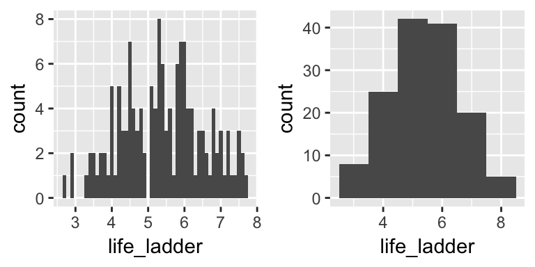

```r
p1 <- ggplot(data = happinessdata2016, aes(x = life_ladder)) +
  geom_histogram(binwidth = 0.1)
p2 <- ggplot(data = happinessdata2016, aes(x = life_ladder)) +
  geom_histogram(binwidth = 1.0)
grid.arrange(p1,p2,nrow = 1)
```

## Mathematical Definition of Histogram

- The bins of the histogram are the intervals: \[[x_0+mh,x_0+(m+1)h).\] \(x_0\) is the origin, \(m = \ldots,-1,0,1,\ldots\) indexes the bins, and \(h = (x_0+(m+1)h) - (x_0+mh)\) is the bin width.
- The bins can be used to construct rectangles with width \(h\) and height \(\hat f(x)\).
- The area of these rectangles is \(h\hat f(x)\).
- The area of the rectangles is the same as the proportion of data in the same bin as \(x\).

## Example - Mathematical Definition of Histogram

```r
dat <- data_frame(x = c(1,2,2.5,3,7))
dat$x
```

```
[1] 1.0 2.0 2.5 3.0 7.0
```

Let \(x_0=0.5, h=0.25, m=1,\dots,29\)

```r
seq(0.5,7.5,by = 0.25)
```

```
 [1] 0.50 0.75 1.00 1.25 1.50 1.75 2.00 2.25 2.50 2.75 3.00 3.25 3.50 3.75
[15] 4.00 4.25 4.50 4.75 5.00 5.25 5.50 5.75 6.00 6.25 6.50 6.75 7.00 7.25
[29] 7.50
```

The bins are: \([0.50,0.75),[0.75,1.00),[1.00,1.25),\ldots,[7.25,7.50).\)

## Example - Mathematical Definition of Histogram

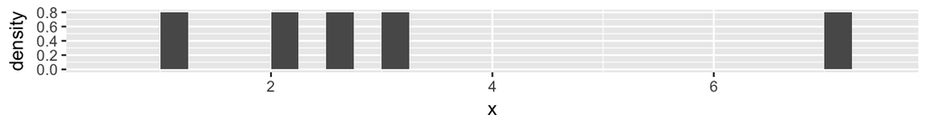

| y | count | x | xmin | xmax | density |
| --- | --- | --- | --- | --- | --- |
| 0.0 | 0 | 0.625 | 0.50 | 0.75 | 0.0 |
| 0.0 | 0 | 0.875 | 0.75 | 1.00 | 0.0 |
| 0.8 | 1 | 1.125 | 1.00 | 1.25 | 0.8 |
| 0.0 | 0 | 1.375 | 1.25 | 1.50 | 0.0 |
| 0.0 | 0 | 1.625 | 1.50 | 1.75 | 0.0 |
| 0.0 | 0 | 1.875 | 1.75 | 2.00 | 0.0 |

## Mathematical Definition of Histogram

- Suppose we have data: \(X_1, X_2, \ldots, X_n\).
- Let \(\#\{X_i \text{ in same bin as } x\}\) be the number of data points \(X_i\) in the same bin as \(x\).
- Let \(n\) be the total number of data points. So, \(\frac{\#\{X_i \text{ in same bin as } x\}}{n}\) is the proportion of data in the same bin as \(x\).
- \(\text{Area of rectangle containing }x \approx \frac{\#\{X_i \text{ in same bin as } x\}}{n}.\)
- \[h \hat f(x) = \frac{\#\{X_i \text{ in same bin as } x\}}{n}.\]

## Mathematical Definition of Histogram

\[\hat f(x) = \frac{1}{hn} \#\{X_i \text{ in same bin as } x\}\] is called the **histogram estimator**.

\(\hat f(x)\) is an estimate of the density at a point \(x\).

To construct the histogram we have to choose an origin \(x_0\) and bin width \(h\).

## Choosing Origin and Bin Width in R

Same bin width but different origin

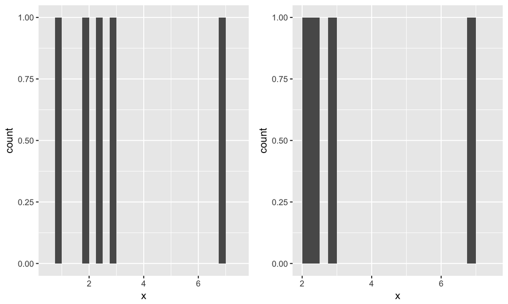

## Naive Estimator of Density

The histogram can be centered on a point \(x\).

\[\hat f(x) = \frac{1}{2hn} \#\{X_i \in (x-h, x+h) \}\] This estimate is often called the **naive estimator** of the density.

This can be expressed by defining the weight function \(w(x)\) by

\[w(x) = \left\{ \begin{array}{ll} 1/2 & \mbox{if } |x| < 1 \\ 0 & \mbox{if } |x| \ge 1. \end{array} \right. \]

Then the naive estimator can be written

\[ \hat f (x) = \frac{1}{n}\sum_{i=1}^n \frac{1}{h}w\left(\frac{x-X_i}{h} \right).\]

## Naive Estimator of Density

\[ \hat f (x) = \frac{1}{n}\sum_{i=1}^n \frac{1}{h}w\left(\frac{x-X_i}{h} \right).\]

- Consider the histogram constructed from data using bins of width \(2h\).
- Assume that \(x\) is at the centre of one of the histogram bins then the naive estimate will be the same as the \(y\) value of the histogram estimate.

## Naive Estimator in R

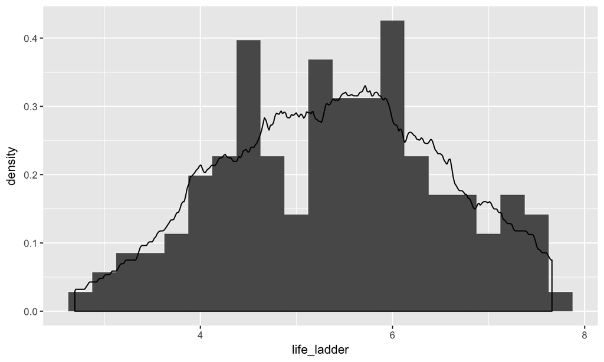

```r
ggplot(data = happinessdata2016, aes(x = life_ladder, ..density..)) +
  geom_histogram(binwidth = 0.25) + geom_density(kernel = "rectangular" )
```

## Kernel Estimator

Replace the weight function is by a kernel function \(K(x) \ge 0\) which satisfies \(\int_{-\infty}^{\infty}K(x)=1.\) The **kernel estimator** of the density function is defined by

\[ \hat f (x) = \frac{1}{n}\sum_{i=1}^n \frac{1}{h}K\left(\frac{x-X_i}{h} \right).\]

The Gaussian kernel is a popular choice \[K(x)=\frac{1}{\sqrt{2\pi}} \exp\left(-x^2/2\right), -\infty<x<\infty.\]

## Kernel Estimator in R

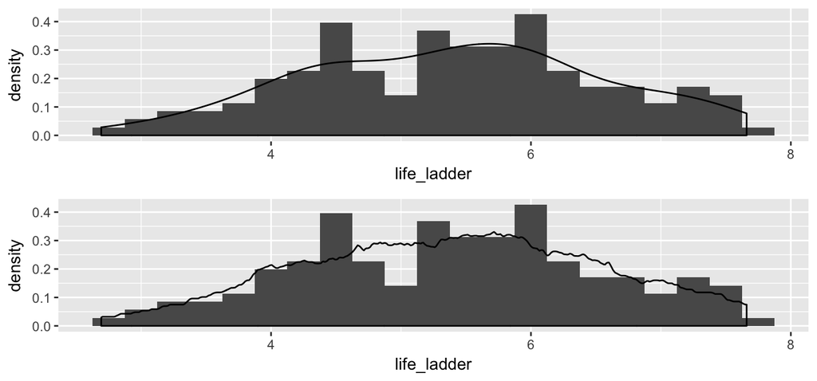

```r
p_gauss <- ggplot(data = happinessdata2016, aes(x = life_ladder, ..density..)) +
  geom_histogram(binwidth = 0.25) + geom_density(kernel = "gaussian" )
p_rect <- ggplot(data = happinessdata2016, aes(x = life_ladder, ..density..)) +
  geom_histogram(binwidth = 0.25) + geom_density(kernel = "rectangular" )
grid.arrange(p_gauss,p_rect)
```